# Hospital_fdrugs

Anton Muromstev

10/24/2021

## Introduction

Clinical trial data was collected in form of multiple csv files. Our aim is to identify whether drugs in this clinical trial have statistically signidicant effect

### Libraries required

If you are working manually please connect libraries in order listed below

```r
if(!require(dplyr)) install.packages("dplyr")
if(!require(ggplot2)) install.packages("ggplot2")
if(!require(ggpubr)) install.packages("ggpubr")
if(!require(nortest)) install.packages("nortest")
if(!require(car)) install.packages("car")
if(!require(tableHTML)) install.packages("tableHTML")
library(dplyr)
library(ggplot2)
library(nortest)
library(ggpubr)
library(car)
library(tableHTML)
```

### Fucntion to bind csv files

At first we created function which receives a path to folder and extension of files in folder. Then it binds all the files with given expenction

```r
results_bind <- function(pathway, extenction) {

  file_names <- list.files(path = pathway, pattern = paste0("*.", extenction))
  if (extenction == "csv") {
    frames <- lapply(file_names, read.csv, na.strings = c("NA", ""))
  } else if (extenction == "tsv") {
    frames <- lapply(file_names, read.table, sep = '\t',
                     header = TRUE, na.strings = c("NA", ""))
  }
  frames_binded <- do.call("rbind", frames)
  final_frame <- as_data_frame(frames_binded)
  return(final_frame)
}
```

This function was used to bind csv files collected from clinical trial

```r
raw_frame <- results_bind("./","csv")
```

### Data preprocessing

We firstly performed structure analysis of created dataframe

```r
str(raw_frame)
```

```
## tibble[,7] [200 × 7] (S3: tbl_df/tbl/data.frame)
##  $ X               : int [1:200] 1 2 3 4 5 6 7 8 9 10 ...
##  $ gender          : chr [1:200] "female" "female" "female" "female" ...
##  $ age             : chr [1:200] "26" "26" "31" "28" ...
##  $ drug_type       : chr [1:200] "Placebo" "Placebo" "Placebo" "Placebo" ...
##  $ is_relapse      : int [1:200] 0 1 0 1 1 NA 0 1 1 0 ...
##  $ id              : int [1:200] 101 102 103 104 105 106 107 108 109 110 ...
##  $ days_in_hospital: num [1:200] 25.2 23.3 29.9 27.8 23.3 ...
```

We replaced NAs in is_relapse to 0 and made some corrections in age and gender variables. Then gender and drug_type were factorised and age type was turned into integer. Thus **filtered_frame (filt_frame)** was created

```r
raw_frame$gender[raw_frame$gender == "malle"] <- "male"
raw_frame$age[raw_frame$age == "thirty-one"] <- "31"
raw_frame$is_relapse[is.na(raw_frame$is_relapse)] <- 0

filt_frame <- filter(raw_frame, age %in% c(1:150)) %>% mutate(gender = as.factor(gender),
                                                        drug_type = as.factor(drug_type),
                                                        age = as.integer(age))
```

Final structure of the dataframe

```r
str(filt_frame)
```

```
## tibble[,7] [198 × 7] (S3: tbl_df/tbl/data.frame)
##  $ X               : int [1:198] 1 2 3 4 5 6 7 8 9 10 ...
##  $ gender          : Factor w/ 2 levels "female","male": 1 1 1 1 1 1 1 1 1 1 ...
##  $ age             : int [1:198] 26 26 31 28 29 30 36 31 31 30 ...
##  $ drug_type       : Factor w/ 4 levels "New_type_1","New_type_2",..: 4 4 4 4 4 4 4 4 4 4 ...
##  $ is_relapse      : num [1:198] 0 1 0 1 1 0 0 1 1 0 ...
##  $ id              : int [1:198] 101 102 103 104 105 106 107 108 109 110 ...
##  $ days_in_hospital: num [1:198] 25.2 23.3 29.9 27.8 23.3 ...
```

### Normality testing

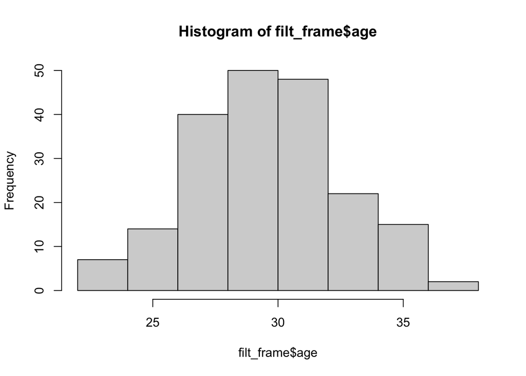

```r
hist(filt_frame$age)
```

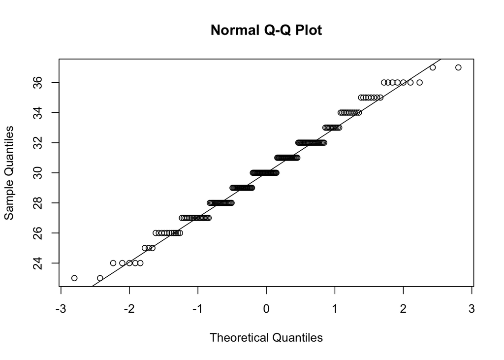

```r
qqnorm(filt_frame$age)
qqline(filt_frame$age)
```

```r
sf.test(filt_frame$age)
```

```
##
##  Shapiro-Francia normality test
##
## data:  filt_frame$age
## W = 0.98639, p-value = 0.05195
```

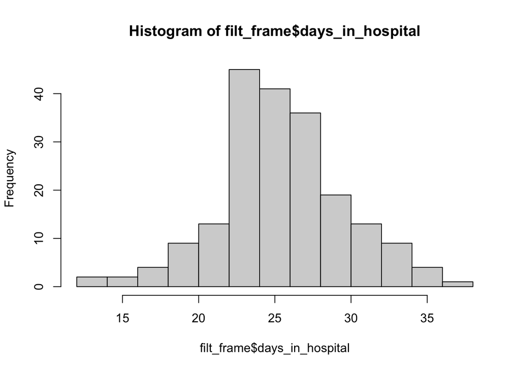

```r
hist(filt_frame$days_in_hospital)
```

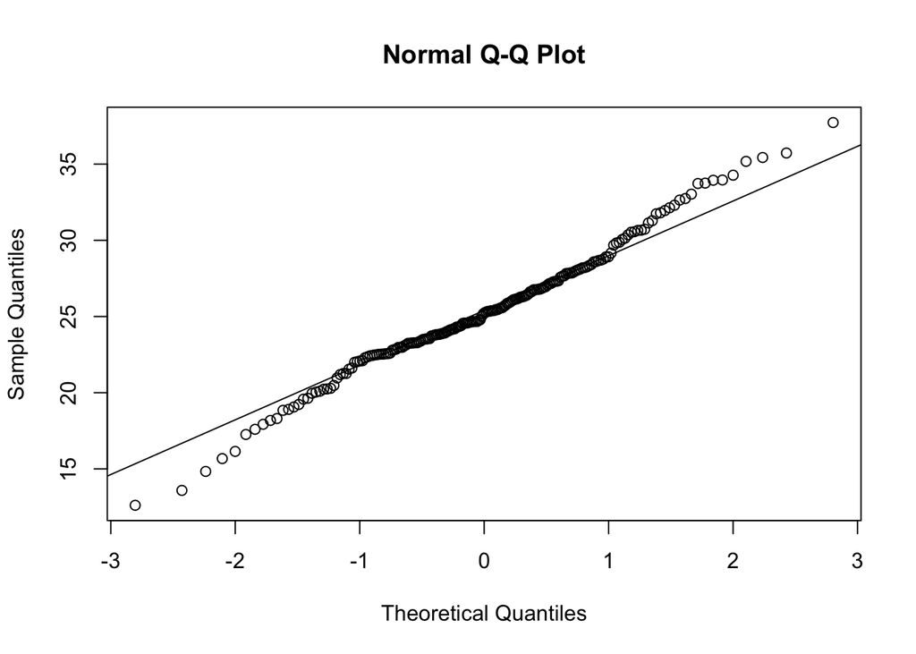

```r
qqnorm(filt_frame$days_in_hospital)
qqline(filt_frame$days_in_hospital)
```

```r
sf.test(filt_frame$days_in_hospital)
```

```
##
##  Shapiro-Francia normality test
##
## data:  filt_frame$days_in_hospital
## W = 0.98702, p-value = 0.06326
```

### EDA

We firsty checked if age and days_in_hospital are connected

```r
cor(filt_frame$age, filt_frame$days_in_hospital, method = "pearson")
```

```
## [1] -0.02312594
```

```r
cor.test(filt_frame$age, filt_frame$days_in_hospital)
```

```
##
##  Pearson's product-moment correlation
##
## data:  filt_frame$age and filt_frame$days_in_hospital
## t = -0.32385, df = 196, p-value = 0.7464
## alternative hypothesis: true correlation is not equal to 0
## 95 percent confidence interval:
##  -0.1620449  0.1166918
## sample estimates:
##         cor
## -0.02312594
```

Then we checked whether gender influence days_in_hospital

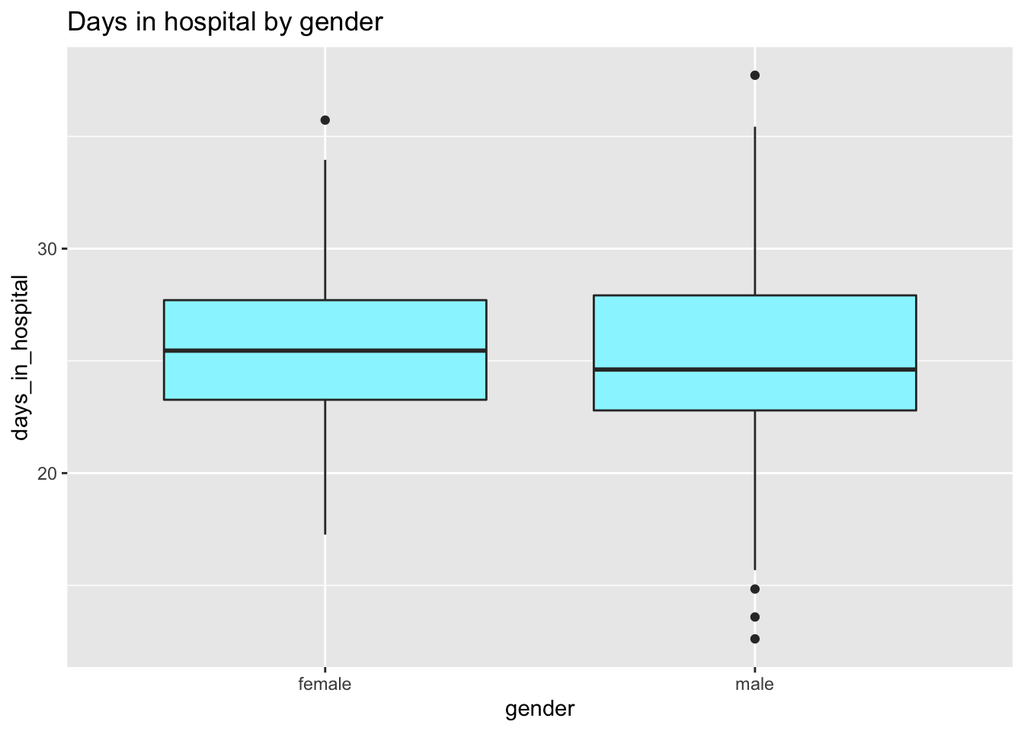

```r
ggplot(filt_frame, aes(x = gender, y = days_in_hospital))+
  geom_boxplot(fill = "cadetblue1")+
  labs(title = "Days in hospital by gender")
```

It seems that gender does not affect days_in_hospital

Then days_in_hospital and drug_type connections were checked

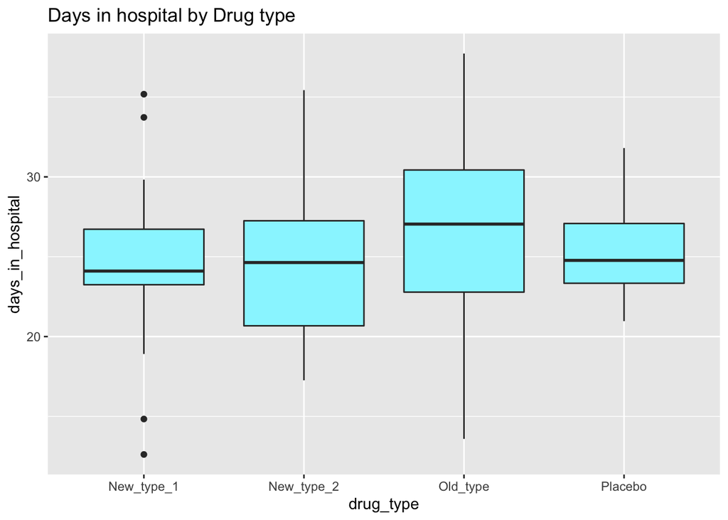

```r
ggplot(filt_frame, aes(x = drug_type, y = days_in_hospital))+
  geom_boxplot(fill = "cadetblue1")+
  labs(title = "Days in hospital by Drug type")
```

Finally we look at relations between drug_type and gender connected with days_in_hospital

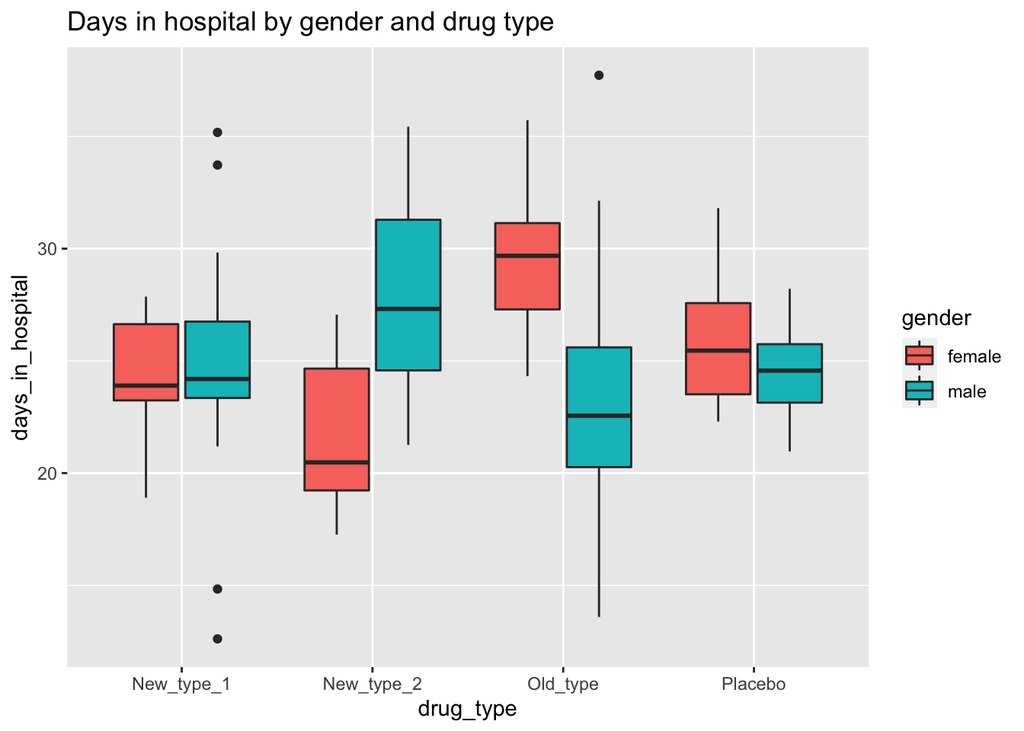

```r
ggplot(filt_frame, aes(x = drug_type, y = days_in_hospital, fill = gender))+
  geom_boxplot()+
  labs(title = "Days in hospital by gender and drug type")
```

It seem that drug (New_type_2) works in a gender-specific manner and cure women more effectively

### days_in_hospital variable basic analysis

we calculated mean and sd of days_in_hospital variable

```r
mean(filt_frame$days_in_hospital)
```

```
## [1] 25.36098
```

```r
sd(filt_frame$days_in_hospital)
```

```
## [1] 4.20093
```

### Testing whether days_in_hospital is different for females with different types

According to EDA results it make sense to perform t-test for women cured with placebo and drug type = New_type2

```r
New_type2 <- filter(filt_frame, gender == "female", drug_type == "New_type_2")
Placebo <- filter(filt_frame, gender == "female", drug_type == "Placebo")
Result <- filter(filt_frame, gender == "female", drug_type %in% c("Placebo", "New_type_2"))
t.test(New_type2$days_in_hospital, Placebo$days_in_hospital)
```

```
##
##  Welch Two Sample t-test
##
## data:  New_type2$days_in_hospital and Placebo$days_in_hospital
## t = -4.7042, df = 44.772, p-value = 2.468e-05
## alternative hypothesis: true difference in means is not equal to 0
## 95 percent confidence interval:
##  -5.530429 -2.214151
## sample estimates:
## mean of x mean of y
##  21.97230  25.84459
```

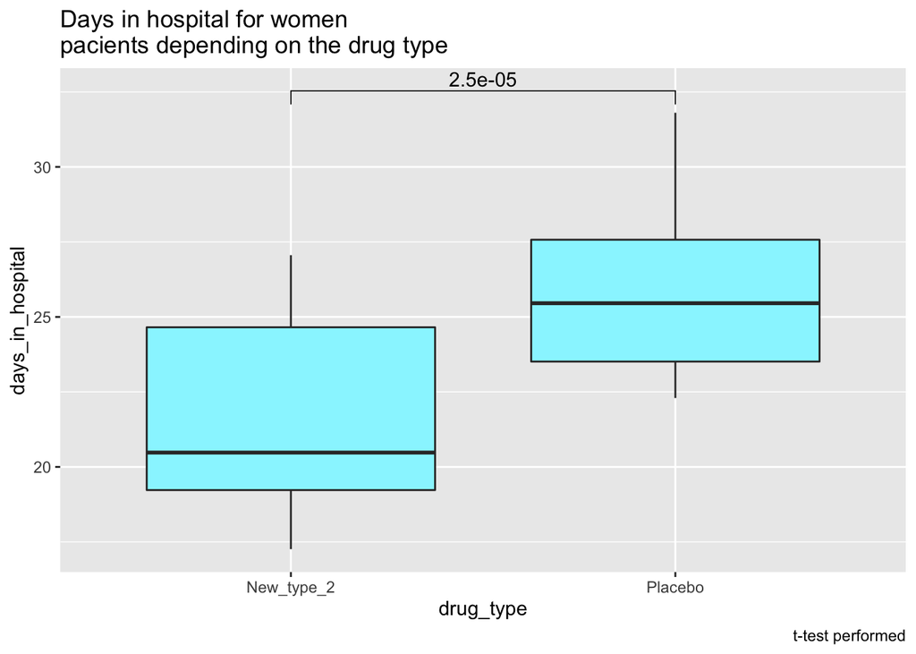

```r
ggplot(Result, aes(x = drug_type, y = days_in_hospital))+
  geom_boxplot(fill = "cadetblue1")+
  stat_compare_means(method = "t.test", comparisons = list(c("Placebo", "New_type_2")))+
  labs(title = "Days in hospital for women \npacients depending on the drug type",
     caption = "t-test performed")
```

According to the test drug = New_type_2 significantly lower days_in hospital for women

### Perform Anova for drug_type and days_in_hospital

```r
An <- lm(days_in_hospital ~ drug_type + gender + drug_type:gender, data = filt_frame)
tableHTML(round(Anova(An), digits = 3))
```

|  | Sum Sq | Df | F value | Pr(>F) |
| --- | --- | --- | --- | --- |
| drug_type | 109.034 | 3 | 2.803 | 0.041 |
| gender | 3.792 | 1 | 0.292 | 0.589 |
| drug_type:gender | 899.269 | 3 | 23.116 | 0 |
| Residuals | 2463.792 | 190 | NA | NA |

drug_type and gender are connected. Additionally it turned out that drug_type is statittically significant itself too.